# Prática Machine Learning - CUNEF

## Alumno: Amadeo Gustavo Ancarani

### Definición del Script: 03_Model_training

Con los datos tratados anteriormente, vamos a realizar las estimaciones de los modelos y seleccionar aquel modelo que en el conjunto de métricas disponibles, genere una mejor clasificación.

# 0. Importar librerías

```python
import pandas as pd
import numpy as np
import matplotlib.pyplot as plt
%matplotlib inline
import seaborn as sns
sns.set()
import warnings
warnings.filterwarnings("ignore")
from sklearn import tree
from sklearn.pipeline import Pipeline

from sklearn.metrics import classification_report, confusion_matrix, roc_curve, auc, \
                            silhouette_score, recall_score, precision_score, make_scorer, \
                            roc_auc_score, f1_score, precision_recall_curve

from sklearn.metrics import accuracy_score, roc_auc_score, \
                            classification_report, confusion_matrix


from sklearn import metrics
from sklearn.metrics import plot_confusion_matrix

from sklearn.ensemble import RandomForestClassifier, GradientBoostingClassifier, AdaBoostClassifier
from sklearn.svm import SVC
from sklearn.tree import DecisionTreeClassifier
from sklearn.linear_model import LogisticRegression
from sklearn.neighbors import KNeighborsClassifier
import pickle
from xgboost import XGBClassifier
from lightgbm import LGBMClassifier
from imblearn.over_sampling import SMOTE
import re

from sklearn.model_selection import GridSearchCV
from catboost import CatBoostClassifier
import random
```

# 1. Importar Datos

```python
train = pd.read_csv("../data/train_data_personal_prob.csv",low_memory=False)
train.set_index(['Unnamed: 0'], inplace=True)
train.index.names = ['']

test = pd.read_csv("../data/test_data_personal_prob.csv",low_memory=False)
test.set_index(['Unnamed: 0'], inplace=True)
test.index.names = ['']
```

```python
train.shape
```

```
(4081586, 23)
```

```python
test.shape
```

```
(1360690, 23)
```

# 2. Separo a mis datasets en variables exógenas (X) y objetivo (y)

```python
ytrain = train['C_SEV']
xtrain = train.drop(columns=['C_SEV'])

ytest = test['C_SEV']
xtest = test.drop(columns=['C_SEV'])
```

```python
xtrain.head()
```

|  | C_YEAR | C_VEHS | C_CONF | C_RCFG | C_WTHR | C_RSUR | V_TYPE | P_SEX | P_AGE | P_PSN | ... | V_YEAR_NNNN | V_YEAR_UUUU | P_AGE_UU | V_ANT | C_HOUR_SIN | C_HOUR_COS | C_WDAY_SIN | C_WDAY_COS | C_MNTH_SIN | C_MNTH_COS |
| --- | --- | --- | --- | --- | --- | --- | --- | --- | --- | --- | --- | --- | --- | --- | --- | --- | --- | --- | --- | --- | --- |
| 4850824 | 2011 | 0.013298 | 0.025305 | 0.027714 | 0.013715 | 0.014277 | 0.014307 | 0.020431 | 31.0 | 0.015287 | ... | 0 | 0 | 0 | 6.0 | 0.965926 | -2.588190e-01 | -0.433884 | -0.900969 | -0.866025 | 0.500000 |
| 3179371 | 2006 | 0.012907 | 0.013763 | 0.011817 | 0.015883 | 0.019240 | 0.014307 | 0.020431 | 44.0 | 0.015287 | ... | 0 | 0 | 0 | 3.0 | 0.707107 | -7.071068e-01 | -0.433884 | -0.900969 | -0.500000 | 0.866025 |
| 5330174 | 2013 | 0.012907 | 0.003711 | 0.027714 | 0.015883 | 0.016904 | 0.014307 | 0.020431 | 18.0 | 0.015287 | ... | 0 | 0 | 0 | 10.0 | -0.707107 | -7.071068e-01 | -0.974928 | -0.222521 | 0.866025 | -0.500000 |
| 4880251 | 2011 | 0.012907 | 0.003711 | 0.027714 | 0.015883 | 0.016904 | 0.014307 | 0.012568 | 27.0 | 0.015287 | ... | 0 | 0 | 0 | 11.0 | -1.000000 | -1.836970e-16 | -0.433884 | -0.900969 | -0.500000 | 0.866025 |
| 3039624 | 2006 | 0.012907 | 0.003711 | 0.009720 | 0.015883 | 0.016904 | 0.014307 | 0.012568 | 36.0 | 0.015287 | ... | 0 | 0 | 0 | 4.0 | -0.258819 | -9.659258e-01 | -0.433884 | -0.900969 | -0.500000 | -0.866025 |

5 rows × 22 columns

```python
xtest.head()
```

|  | C_YEAR | C_VEHS | C_CONF | C_RCFG | C_WTHR | C_RSUR | V_TYPE | P_SEX | P_AGE | P_PSN | ... | V_YEAR_NNNN | V_YEAR_UUUU | P_AGE_UU | V_ANT | C_HOUR_SIN | C_HOUR_COS | C_WDAY_SIN | C_WDAY_COS | C_MNTH_SIN | C_MNTH_COS |
| --- | --- | --- | --- | --- | --- | --- | --- | --- | --- | --- | --- | --- | --- | --- | --- | --- | --- | --- | --- | --- | --- |
| 87310 | 1999 | 0.012907 | 0.012065 | 0.009720 | 0.015883 | 0.014277 | 0.014307 | 0.012568 | 3.0 | 0.015287 | ... | 0 | 0 | 0 | 6.0 | 7.071068e-01 | -7.071068e-01 | -2.449294e-16 | 1.000000 | 1.000000 | 6.123234e-17 |
| 2333390 | 2004 | 0.012907 | 0.018530 | 0.027714 | 0.020966 | 0.016904 | 0.014307 | 0.020431 | 43.0 | 0.015287 | ... | 0 | 0 | 0 | 15.0 | 1.224647e-16 | -1.000000e+00 | 9.749279e-01 | -0.222521 | -1.000000 | -1.836970e-16 |
| 1485833 | 2002 | 0.013298 | 0.003711 | 0.011817 | 0.015883 | 0.016904 | 0.014307 | 0.012568 | 25.0 | 0.015287 | ... | 0 | 0 | 0 | 16.0 | -5.000000e-01 | 8.660254e-01 | 9.749279e-01 | -0.222521 | -0.866025 | -5.000000e-01 |
| 1155103 | 2001 | 0.012907 | 0.003711 | 0.027714 | 0.015883 | 0.016904 | 0.014307 | 0.020431 | 46.0 | 0.015287 | ... | 0 | 0 | 0 | 13.0 | -1.000000e+00 | -1.836970e-16 | -4.338837e-01 | -0.900969 | -0.866025 | 5.000000e-01 |
| 3970807 | 2009 | 0.012907 | 0.013763 | 0.011817 | 0.015883 | 0.019240 | 0.014307 | 0.020431 | 45.0 | 0.015287 | ... | 0 | 0 | 0 | 5.0 | 1.000000e+00 | 6.123234e-17 | 4.338837e-01 | -0.900969 | 0.866025 | 5.000000e-01 |

5 rows × 22 columns

# 3. Observo las distribuciones de los fallecidos

```python
ytrain.value_counts()/len(ytrain)
```

```
0    0.983254
1    0.016746
Name: C_SEV, dtype: float64
```

```python
ytest.value_counts()/len(ytest)
```

```
0    0.983176
1    0.016824
Name: C_SEV, dtype: float64
```

# 4. Defino la función para obtener las métricas a utilizar para evaluar los modelos.

```python
def evaluate_model(ytest, ypred, ypred_proba = None):
    if ypred_proba is not None:
        print('ROC-AUC score of the model: {}'.format(roc_auc_score(ytest, ypred_proba[:, 1])))
    print('')
    print('Accuracy of the model: {}\n'.format(accuracy_score(ytest, ypred)))

    score = f1_score(ytest, ypred)
    print('F-Score: %.5f' % score)
    print('')
    print('Classification report: \n{}\n'.format(classification_report(ytest, ypred)))
    #print('Confusion matrix: \n{}\n'.format(confusion_matrix(ytest, ypred)))


    print('Confusion matrix:')
    cm_gbt = confusion_matrix(ytest, ypred)

    plt.figure(figsize=(9,9))
    sns.heatmap(cm_gbt, annot=True, fmt=".0f", linewidths=.5, square = True, cmap = 'Blues_r');
    plt.ylabel('Actual label')
    plt.show();
```

# 5. Entrenamiento de modelos

### En los proximos 4 bloques entreno los modelos y genero los reports de métricas

El primer bloque captará el modelo base (decisión al azar).

```
The model presented is: Random Values



Accuracy of the model: 0.5010406484945138

F-Score: 0.03215

Classification report:
              precision    recall  f1-score   support

           0       0.98      0.50      0.66   1337798
           1       0.02      0.49      0.03     22892

    accuracy                           0.50   1360690
   macro avg       0.50      0.50      0.35   1360690
weighted avg       0.97      0.50      0.65   1360690


Confusion matrix:
```

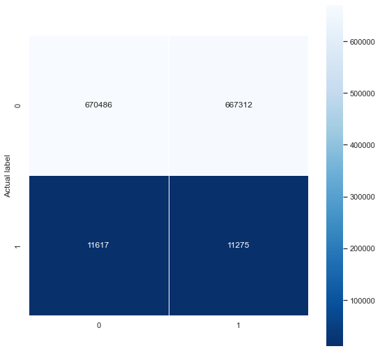

```python
print('The model presented is: Random Values')
print('')


randomlist = []
for i in range(0,len(ytest)):
    n = random.randint(0,1)
    randomlist.append(n)


print('')
evaluate_model(ytest=ytest, ypred=randomlist, ypred_proba = None)
print('')
```

## Ahora genero los modelo de machine learning

```
The model presented is: LogisticRegression(n_jobs=-1)

model score: 0.983

ROC-AUC score of the model: 0.6176630528823108

Accuracy of the model: 0.9831761826720267

F-Score: 0.00000

Classification report:
              precision    recall  f1-score   support

           0       0.98      1.00      0.99   1337798
           1       0.00      0.00      0.00     22892

    accuracy                           0.98   1360690
   macro avg       0.49      0.50      0.50   1360690
weighted avg       0.97      0.98      0.97   1360690


Confusion matrix:
```

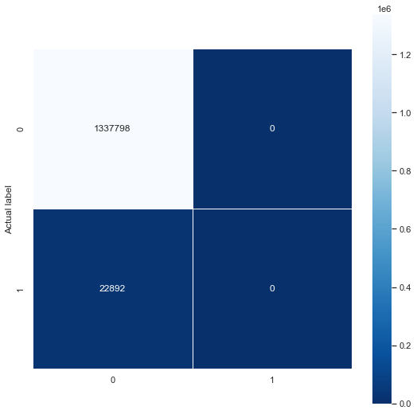

```
ROC Curve:
```

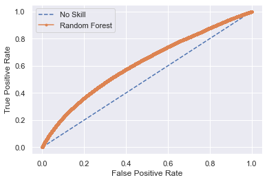

```
-----------------------------------------------------------
The model presented is: DecisionTreeClassifier()

model score: 0.972

ROC-AUC score of the model: 0.649663225026313

Accuracy of the model: 0.9720252224974094

F-Score: 0.27546

Classification report:
              precision    recall  f1-score   support

           0       0.99      0.98      0.99   1337798
           1       0.24      0.32      0.28     22892

    accuracy                           0.97   1360690
   macro avg       0.62      0.65      0.63   1360690
weighted avg       0.98      0.97      0.97   1360690


Confusion matrix:
```

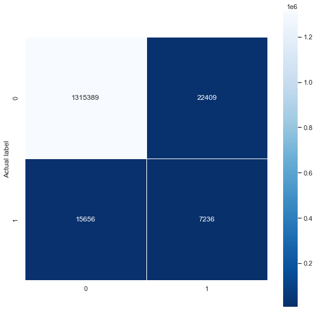

```
ROC Curve:
```

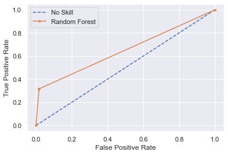

```
-----------------------------------------------------------
The model presented is: RandomForestClassifier(n_jobs=-1, random_state=158)

model score: 0.986

ROC-AUC score of the model: 0.8934295527795523

Accuracy of the model: 0.9855257259184679

F-Score: 0.25106

Classification report:
              precision    recall  f1-score   support

           0       0.99      1.00      0.99   1337798
           1       0.97      0.14      0.25     22892

    accuracy                           0.99   1360690
   macro avg       0.98      0.57      0.62   1360690
weighted avg       0.99      0.99      0.98   1360690


Confusion matrix:
```

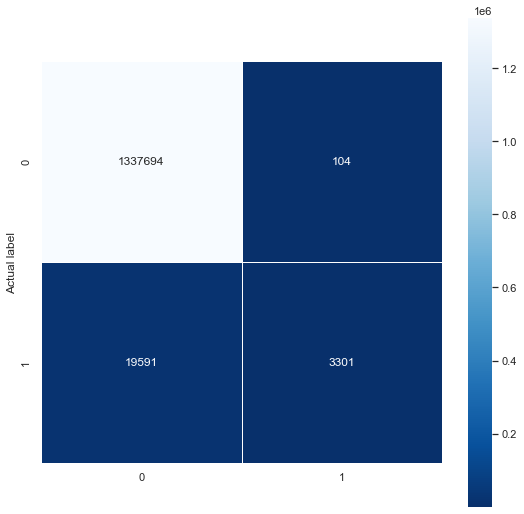

```
ROC Curve:
```

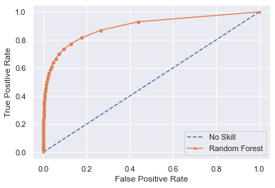

```
-----------------------------------------------------------
The model presented is: AdaBoostClassifier(random_state=158)

model score: 0.983

ROC-AUC score of the model: 0.8131225743282963

Accuracy of the model: 0.9831115096017462

F-Score: 0.01845

Classification report:
              precision    recall  f1-score   support

           0       0.98      1.00      0.99   1337798
           1       0.42      0.01      0.02     22892

    accuracy                           0.98   1360690
   macro avg       0.70      0.50      0.50   1360690
weighted avg       0.97      0.98      0.98   1360690


Confusion matrix:
```

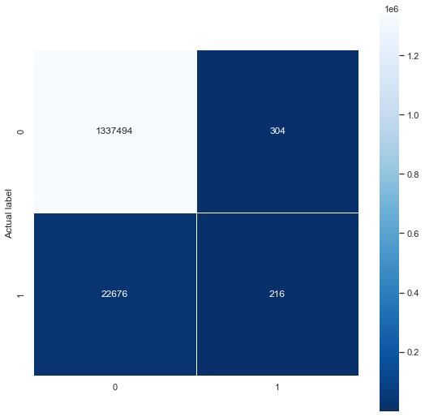

```
ROC Curve:
```

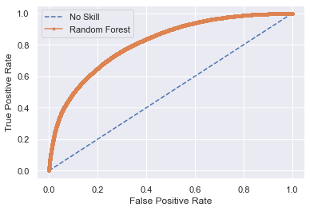

```
-----------------------------------------------------------
The model presented is: GradientBoostingClassifier(random_state=158)

model score: 0.983

ROC-AUC score of the model: 0.8225718185810936

Accuracy of the model: 0.9832768668837134

F-Score: 0.01931

Classification report:
              precision    recall  f1-score   support

           0       0.98      1.00      0.99   1337798
           1       0.72      0.01      0.02     22892

    accuracy                           0.98   1360690
   macro avg       0.85      0.50      0.51   1360690
weighted avg       0.98      0.98      0.98   1360690


Confusion matrix:
```

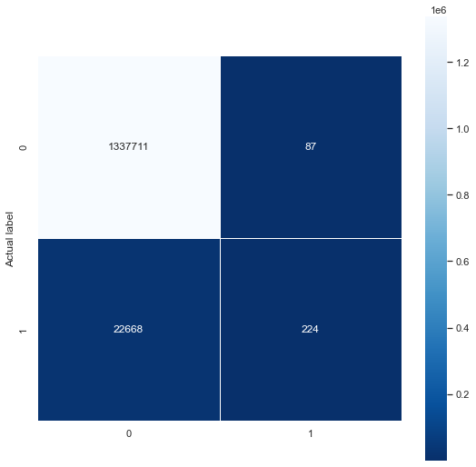

```
ROC Curve:
```

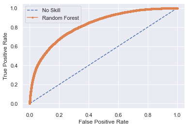

```
-----------------------------------------------------------
The model presented is: LGBMClassifier(random_state=158)

model score: 0.983

ROC-AUC score of the model: 0.8407164370088412

Accuracy of the model: 0.983384900307932

F-Score: 0.03558

Classification report:
              precision    recall  f1-score   support

           0       0.98      1.00      0.99   1337798
           1       0.76      0.02      0.04     22892

    accuracy                           0.98   1360690
   macro avg       0.87      0.51      0.51   1360690
weighted avg       0.98      0.98      0.98   1360690


Confusion matrix:
```

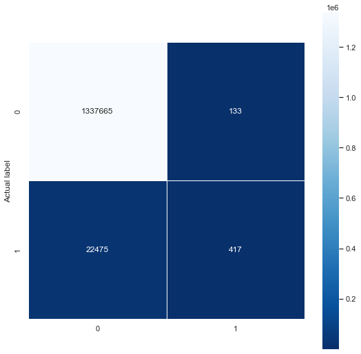

```
ROC Curve:
```

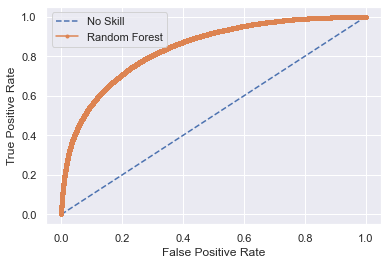

```python
classifiers = [
    LogisticRegression(n_jobs=-1),
    DecisionTreeClassifier(),
    RandomForestClassifier(n_jobs=-1, random_state=158),
    AdaBoostClassifier(random_state=158),
    GradientBoostingClassifier(random_state=158),
    #XGBClassifier(),
    LGBMClassifier(random_state=158, n_jobs=-1)
    ]

for classifier in classifiers:

    pipe = Pipeline(steps=[('classifier', classifier)])
    pipe.fit(xtrain, ytrain)

    print('The model presented is:', classifier)
    print('')
    print("model score: %.3f" % pipe.score(xtest, ytest))

    ypred = pipe.predict(xtest)
    ypred_proba = pipe.predict_proba(xtest)

    print('')
    evaluate_model(ytest=ytest, ypred=ypred, ypred_proba = ypred_proba)
    print('')

    yhat = ypred_proba[:, 1]
    # calculate roc curves
    fpr, tpr, thresholds = roc_curve(ytest, yhat)
    # plot the roc curve for the model
    print('ROC Curve:')
    plt.plot([0,1], [0,1], linestyle='--', label='No Skill')
    plt.plot(fpr, tpr, marker='.', label='Random Forest')
    # axis labels
    plt.xlabel('False Positive Rate')
    plt.ylabel('True Positive Rate')
    plt.legend()
    # show the plot
    plt.show();

    filename  = '../models/' + re.sub(r"\([^()]*\)", '', str(classifier)) + '_personal_prob.pickle'
    pickle.dump(pipe['classifier'], open(filename, 'wb'))

    print('-----------------------------------------------------------')
```

**Los modelos siguientes necesitan ciertos ajustes a aplicar en el bucle, por lo tanto los entrenamos de forma separada.**

```
[19:55:35] WARNING: ..\src\learner.cc:1115: Starting in XGBoost 1.3.0, the default evaluation metric used with the objective 'binary:logistic' was changed from 'error' to 'logloss'. Explicitly set eval_metric if you'd like to restore the old behavior.
The model presented is: XGBClassifier(base_score=0.5, booster='gbtree', colsample_bylevel=1,
              colsample_bynode=1, colsample_bytree=1, enable_categorical=False,
              gamma=0, gpu_id=-1, importance_type=None,
              interaction_constraints='', learning_rate=0.300000012,
              max_delta_step=0, max_depth=6, min_child_weight=1, missing=nan,
              monotone_constraints='()', n_estimators=100, n_jobs=8,
              num_parallel_tree=1, predictor='auto', random_state=0,
              reg_alpha=0, reg_lambda=1, scale_pos_weight=1, subsample=1,
              tree_method='exact', validate_parameters=1, verbosity=None)

model score: 0.984

ROC-AUC score of the model: 0.8501034691155295

Accuracy of the model: 0.9835142464484931

F-Score: 0.04852

Classification report:
              precision    recall  f1-score   support

           0       0.98      1.00      0.99   1337798
           1       0.84      0.02      0.05     22892

    accuracy                           0.98   1360690
   macro avg       0.91      0.51      0.52   1360690
weighted avg       0.98      0.98      0.98   1360690


Confusion matrix:
```

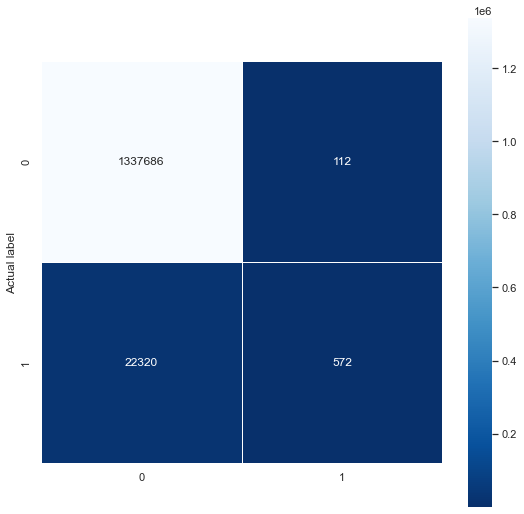

```
ROC Curve:
```

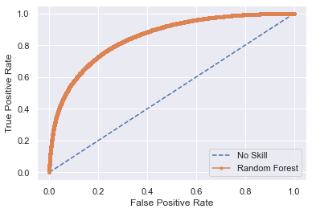

```python
XGBClassifier_list = [
    #LogisticRegression(n_jobs=-1),
    #DecisionTreeClassifier(),
    #RandomForestClassifier(n_jobs=-1, random_state=158),
    #AdaBoostClassifier(random_state=158),
    #GradientBoostingClassifier(random_state=158),
    XGBClassifier()#,
    #LGBMClassifier(random_state=158, n_jobs=-1)
    ]

for classifier in XGBClassifier_list:

    pipe = Pipeline(steps=[('classifier', classifier)])
    pipe.fit(xtrain, ytrain)

    print('The model presented is:', classifier)
    print('')
    print("model score: %.3f" % pipe.score(xtest, ytest))

    ypred = pipe.predict(xtest)
    ypred_proba = pipe.predict_proba(xtest)

    print('')
    evaluate_model(ytest=ytest, ypred=ypred, ypred_proba = ypred_proba)
    print('')

    yhat = ypred_proba[:, 1]
    # calculate roc curves
    fpr, tpr, thresholds = roc_curve(ytest, yhat)
    # plot the roc curve for the model
    print('ROC Curve:')
    plt.plot([0,1], [0,1], linestyle='--', label='No Skill')
    plt.plot(fpr, tpr, marker='.', label='Random Forest')
    # axis labels
    plt.xlabel('False Positive Rate')
    plt.ylabel('True Positive Rate')
    plt.legend()
    # show the plot
    plt.show();

    filename  = '../models/' + 'XGBClassifier_personal_prob' + '.pickle'
    pickle.dump(pipe['classifier'], open(filename, 'wb'))

    print('-----------------------------------------------------------')
```

[output not shown]

[output cut: 968 more lines]

```

F-Score: 0.09102

Classification report:
              precision    recall  f1-score   support

           0       0.98      1.00      0.99   1337798
           1       0.80      0.05      0.09     22892

    accuracy                           0.98   1360690
   macro avg       0.89      0.52      0.54   1360690
weighted avg       0.98      0.98      0.98   1360690


Confusion matrix:
```

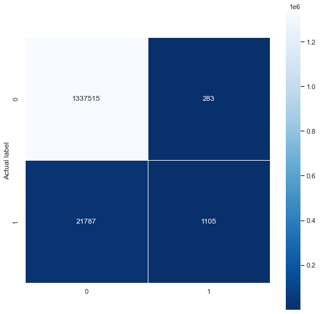

```
ROC Curve:
```

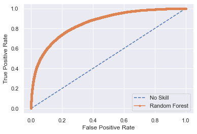

```python
CBClassifier_list = [
    #LogisticRegression(n_jobs=-1),
    #DecisionTreeClassifier(),
    #RandomForestClassifier(n_jobs=-1, random_state=158),
    #AdaBoostClassifier(random_state=158),
    #GradientBoostingClassifier(random_state=158),
    #XGBClassifier()#,
    #LGBMClassifier(random_state=158, n_jobs=-1)
    CatBoostClassifier()
    ]

for classifier in CBClassifier_list:

    pipe = Pipeline(steps=[('classifier', classifier)])
    pipe.fit(xtrain, ytrain)

    print('The model presented is:', classifier)
    print('')
    print("model score: %.3f" % pipe.score(xtest, ytest))

    ypred = pipe.predict(xtest)
    ypred_proba = pipe.predict_proba(xtest)

    print('')
    evaluate_model(ytest=ytest, ypred=ypred, ypred_proba = ypred_proba)
    print('')

    yhat = ypred_proba[:, 1]
    # calculate roc curves
    fpr, tpr, thresholds = roc_curve(ytest, yhat)
    # plot the roc curve for the model
    print('ROC Curve:')
    plt.plot([0,1], [0,1], linestyle='--', label='No Skill')
    plt.plot(fpr, tpr, marker='.', label='Random Forest')
    # axis labels
    plt.xlabel('False Positive Rate')
    plt.ylabel('True Positive Rate')
    plt.legend()
    # show the plot
    plt.show();

    filename  = '../models/' + 'CatBoostClassifier_personal_prob' + '.pickle'
    pickle.dump(pipe['classifier'], open(filename, 'wb'))

    print('-----------------------------------------------------------')
```

# 6. Selección del mejor modelo

Considero que el modelo ganador en este punto es el RandomForest. Si bien la matriz de confusión es mejor en el Árbol de Desición, considero que la forma de la curva de ROC es mucho mejor en el RandomForest y esto más que compensa el menor desempeño clasificatiorio a priori.

Además, un modelo RandomForest esta formado internamente por múltiples Árboles, con lo cual, podríamos obtener valores muy similares ajustando los hiperparámetros.

# 7. Importo los modelos entrenados anteriormente

Esto es para realizar nuevas métricas como es la matriz de confusión normalizada.

#### El cambio más importante para realizar la evaluación es que se toma el threshold óptimo para cada clasificador, con lo cual es una comparación más objetiva.

```python
model_list = ['LogisticRegression', 'DecisionTreeClassifier', 'RandomForestClassifier',
               'AdaBoostClassifier', 'GradientBoostingClassifier', 'XGBClassifier', 'LGBMClassifier']
```

```python
unpickeled_models = []
for model in list(model_list):
    ''' use after the model is pickled '''
    classifier_f = open('../models/'+ model +'_personal_prob.pickle',"rb")
    unpickeled_models.append(pickle.load(classifier_f))
    classifier_f.close()
```

```python
unpickeled_models
```

```
[LogisticRegression(n_jobs=-1),
 DecisionTreeClassifier(),
 RandomForestClassifier(n_jobs=-1, random_state=158),
 AdaBoostClassifier(random_state=158),
 GradientBoostingClassifier(random_state=158),
 XGBClassifier(base_score=0.5, booster='gbtree', colsample_bylevel=1,
               colsample_bynode=1, colsample_bytree=1, enable_categorical=False,
               gamma=0, gpu_id=-1, importance_type=None,
               interaction_constraints='', learning_rate=0.300000012,
               max_delta_step=0, max_depth=6, min_child_weight=1, missing=nan,
               monotone_constraints='()', n_estimators=100, n_jobs=8,
               num_parallel_tree=1, predictor='auto', random_state=0,
               reg_alpha=0, reg_lambda=1, scale_pos_weight=1, subsample=1,
               tree_method='exact', validate_parameters=1, verbosity=None),
 LGBMClassifier(random_state=158)]
```

```
The model is: LogisticRegression(n_jobs=-1)


Accuracy of the model: 0.6057360603811301

F-Score: 0.04626

Classification report:
              precision    recall  f1-score   support

           0       0.99      0.61      0.75   1337798
           1       0.02      0.57      0.05     22892

    accuracy                           0.61   1360690
   macro avg       0.51      0.59      0.40   1360690
weighted avg       0.97      0.61      0.74   1360690


Confusion matrix:
```

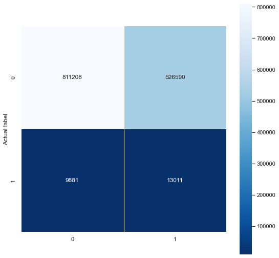

```
Confusion matrix normalized:
```

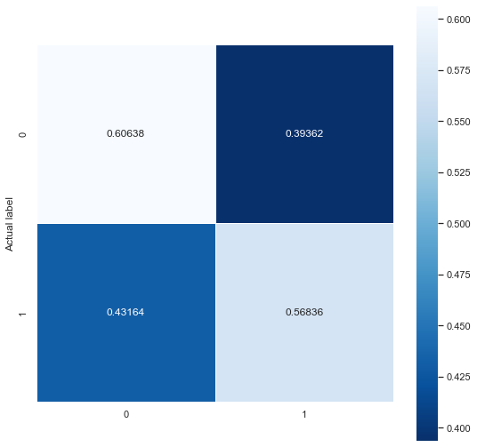

```
---------------------------------------------------------
The model is: DecisionTreeClassifier()


Accuracy of the model: 0.9720252224974094

F-Score: 0.27546

Classification report:
              precision    recall  f1-score   support

           0       0.99      0.98      0.99   1337798
           1       0.24      0.32      0.28     22892

    accuracy                           0.97   1360690
   macro avg       0.62      0.65      0.63   1360690
weighted avg       0.98      0.97      0.97   1360690


Confusion matrix:
```

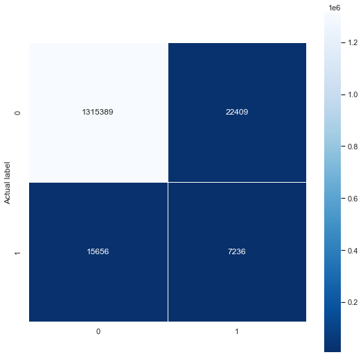

```
Confusion matrix normalized:
```

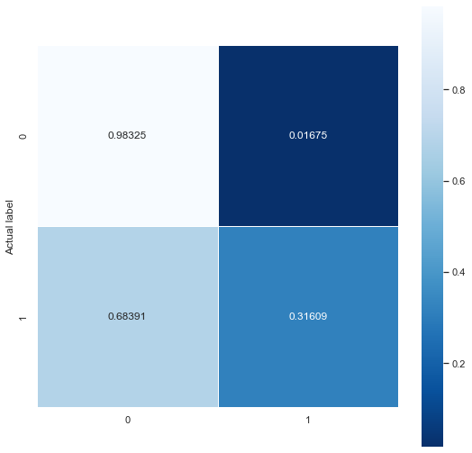

```
---------------------------------------------------------
The model is: RandomForestClassifier(n_jobs=-1, random_state=158)


Accuracy of the model: 0.8715313554152673

F-Score: 0.16832

Classification report:
              precision    recall  f1-score   support

           0       1.00      0.87      0.93   1337798
           1       0.09      0.77      0.17     22892

    accuracy                           0.87   1360690
   macro avg       0.55      0.82      0.55   1360690
weighted avg       0.98      0.87      0.92   1360690


Confusion matrix:
```

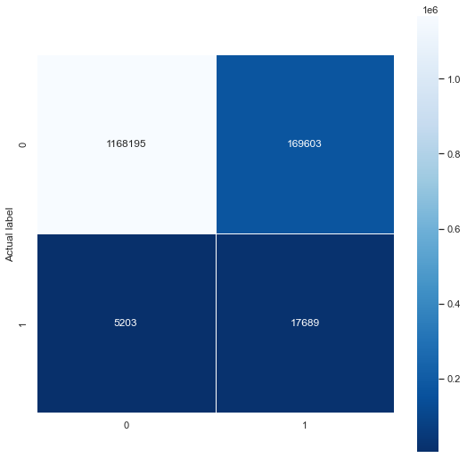

```
Confusion matrix normalized:
```

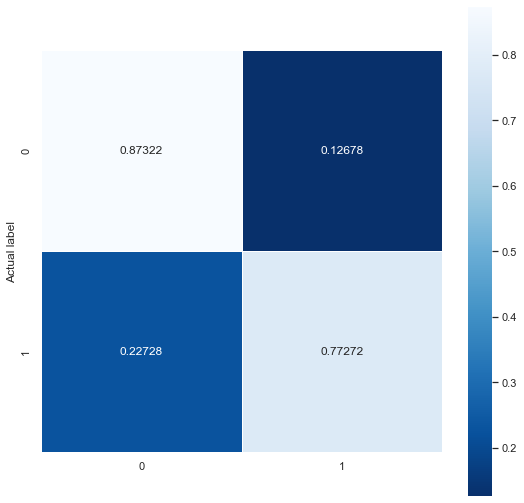

```
---------------------------------------------------------
The model is: AdaBoostClassifier(random_state=158)


Accuracy of the model: 0.7249299987506339

F-Score: 0.08284

Classification report:
              precision    recall  f1-score   support

           0       0.99      0.72      0.84   1337798
           1       0.04      0.74      0.08     22892

    accuracy                           0.72   1360690
   macro avg       0.52      0.73      0.46   1360690
weighted avg       0.98      0.72      0.83   1360690


Confusion matrix:
```

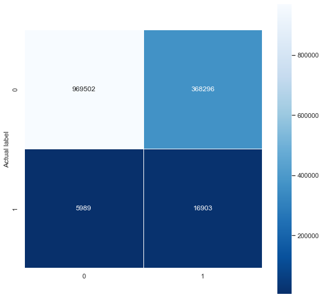

```
Confusion matrix normalized:
```

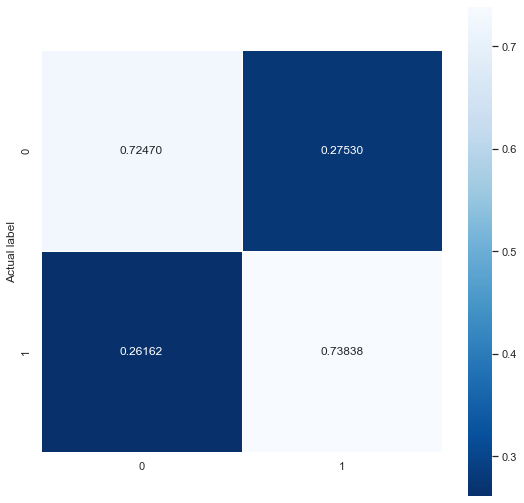

```
---------------------------------------------------------
The model is: GradientBoostingClassifier(random_state=158)


Accuracy of the model: 0.7518501642549

F-Score: 0.08990

Classification report:
              precision    recall  f1-score   support

           0       0.99      0.75      0.86   1337798
           1       0.05      0.73      0.09     22892

    accuracy                           0.75   1360690
   macro avg       0.52      0.74      0.47   1360690
weighted avg       0.98      0.75      0.84   1360690


Confusion matrix:
```

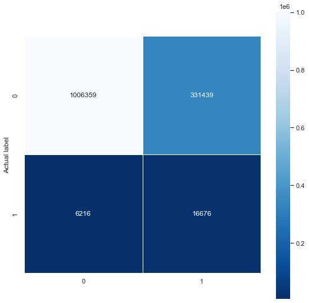

```
Confusion matrix normalized:
```

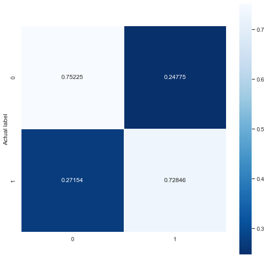

```
---------------------------------------------------------
The model is: XGBClassifier(base_score=0.5, booster='gbtree', colsample_bylevel=1,
              colsample_bynode=1, colsample_bytree=1, enable_categorical=False,
              gamma=0, gpu_id=-1, importance_type=None,
              interaction_constraints='', learning_rate=0.300000012,
              max_delta_step=0, max_depth=6, min_child_weight=1, missing=nan,
              monotone_constraints='()', n_estimators=100, n_jobs=8,
              num_parallel_tree=1, predictor='auto', random_state=0,
              reg_alpha=0, reg_lambda=1, scale_pos_weight=1, subsample=1,
              tree_method='exact', validate_parameters=1, verbosity=None)


Accuracy of the model: 0.7596469438299687

F-Score: 0.09759

Classification report:
              precision    recall  f1-score   support

           0       0.99      0.76      0.86   1337798
           1       0.05      0.77      0.10     22892

    accuracy                           0.76   1360690
   macro avg       0.52      0.77      0.48   1360690
weighted avg       0.98      0.76      0.85   1360690


Confusion matrix:
```

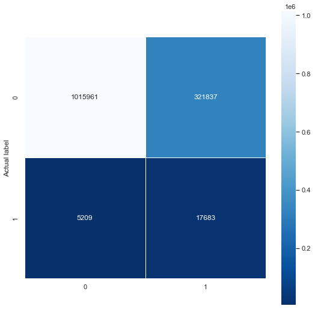

```
Confusion matrix normalized:
```

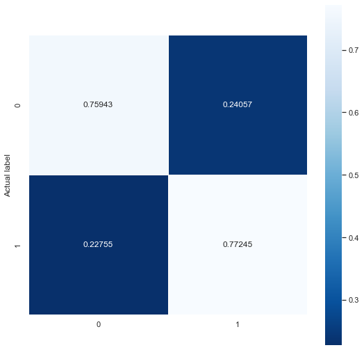

```
---------------------------------------------------------
The model is: LGBMClassifier(random_state=158)


Accuracy of the model: 0.7681029477691466

F-Score: 0.09753

Classification report:
              precision    recall  f1-score   support

           0       0.99      0.77      0.87   1337798
           1       0.05      0.74      0.10     22892

    accuracy                           0.77   1360690
   macro avg       0.52      0.76      0.48   1360690
weighted avg       0.98      0.77      0.85   1360690


Confusion matrix:
```

[2 more figures not shown]

```python
for i in unpickeled_models:
    print('The model is:', i)
    print('')
    ypred_proba = i.predict_proba(xtest)
    yhat = ypred_proba[:, 1]
    # calculate optimized threshold
    fpr, tpr, thresholds = roc_curve(ytest, yhat)
    # calculate the g-mean for each threshold
    gmeans = np.sqrt(tpr * (1-fpr))
    # locate the index of the largest g-mean
    ix = np.argmax(gmeans)
    y_pred_best = (i.predict_proba(xtest)[:,1] >= thresholds[ix]).astype(bool)
    evaluate_model(ypred=y_pred_best, ytest=ytest)
    print('')

    print('Confusion matrix normalized:')
    cm_gbt = confusion_matrix(ytest, y_pred_best, normalize='true')
    print('')
    plt.figure(figsize=(9,9))
    sns.heatmap(cm_gbt, annot=True, fmt='.5f', linewidths=.5, square = True, cmap = 'Blues_r');
    plt.ylabel('Actual label')
    plt.show();
    print('---------------------------------------------------------')
```

### Nuevamente y de manera más directa, el modelo óptimo es el RandomForest

# 8. Optimización de hiperparámetros del modelo ganador: RandomForest

```python
model = RandomForestClassifier()

param_grid = {
    'n_estimators': [200], #, 500],
    'max_features': ['auto', 'sqrt'], #, 'log2'],
    'max_depth' : [6,7], #,6,7,8],
    'criterion' : ['gini', 'entropy']
}


grid_search = GridSearchCV(
    estimator=model,
    param_grid=param_grid,
    n_jobs = -1,
    cv = 2,
    verbose=4
)
```

```python
grid_search.fit(xtrain, ytrain)
```

```
Fitting 2 folds for each of 8 candidates, totalling 16 fits
```

```
GridSearchCV(cv=2, estimator=RandomForestClassifier(), n_jobs=-1,
             param_grid={'criterion': ['gini', 'entropy'], 'max_depth': [6, 7],
                         'max_features': ['auto', 'sqrt'],
                         'n_estimators': [200]},
             verbose=4)
```

```python
grid_search.best_estimator_
```

```
RandomForestClassifier(max_depth=7, n_estimators=200)
```

```
The model presented is: RandomForestClassifier(max_depth=7, n_estimators=200)

model score: 0.983

ROC-AUC score of the model: 0.8071305700644897

Accuracy of the model: 0.9832776018049666

F-Score: 0.01198

Classification report:
              precision    recall  f1-score   support

           0       0.98      1.00      0.99   1337798
           1       1.00      0.01      0.01     22892

    accuracy                           0.98   1360690
   macro avg       0.99      0.50      0.50   1360690
weighted avg       0.98      0.98      0.98   1360690


Confusion matrix:
```

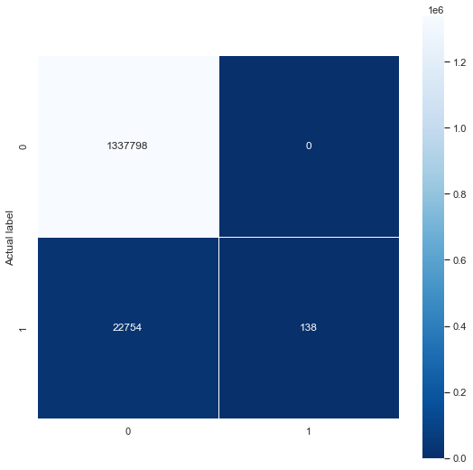

```
ROC Curve:
```

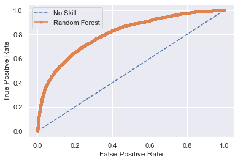

```python
pipe = Pipeline(steps=[('classifier', grid_search.best_estimator_)])

#pipe.fit(xtrain, ytrain)

print('The model presented is:', pipe['classifier'])
print('')
print("model score: %.3f" % pipe.score(xtest, ytest))

ypred = pipe.predict(xtest)
ypred_proba = pipe.predict_proba(xtest)

print('')
evaluate_model(ytest=ytest, ypred=ypred, ypred_proba = ypred_proba)
print('')

yhat = ypred_proba[:, 1]
# calculate roc curves
fpr, tpr, thresholds = roc_curve(ytest, yhat)
# plot the roc curve for the model
print('ROC Curve:')
plt.plot([0,1], [0,1], linestyle='--', label='No Skill')
plt.plot(fpr, tpr, marker='.', label='Random Forest')
# axis labels
plt.xlabel('False Positive Rate')
plt.ylabel('True Positive Rate')
plt.legend()
# show the plot
plt.show();

filename  = '../models/' + 'grid_search' + '.pickle'
pickle.dump(pipe['classifier'], open(filename, 'wb'))

print('-----------------------------------------------------------')
```